# Linear Regression Analysis

ruhil

2018-04-02

Linear regression is useful for describing and predicting how a set of *independent variables* explain variation in (and predict) the *dependent variable*. The dependent variable can be continuous or categorical, and so also the independent variables. Since the goal, as always, is to estimate the true linear relationship between these variables by way of the sample we draw a distinction between the **population regression function (PRF)** and the **sample regression function (SRF)**:

$$\text{PRF: } y = \alpha + \beta(x) + \epsilon$$

$$\text{SRF: } \hat{y} = \hat{a} + \hat{b}(x) + e$$

A couple of things to bear in mind:

- $\epsilon$ and $e$ are the random errors present in every measurement of $y$ in the population and in the sample, respectively. These errors are random in that they cannot be predicted by any independent variable
- The relationships are assumed to be linear. Linearity here means that $b$ does not appear with a power greater than $1$. Thus models such as $y = a + b(x^2) + e$, $y = a + b(\dfrac{1}{x}) + e$, $y = a + b_1(x) + b_2(x^2) + e$, etc. are all linear but models such as $y = a + b^{1/2}(x) + e$ are not linear.
- Several assumptions underlie the linear regression model but the major one tends to be: Constant variance of the residuals (no heteroscedasticity). Heteroscedasticity leads to incorrect standard errors, and hence incorrect t-values which ultimately lead to our drawing wrong conclusions for hypothesis tests since the p-values are off.

# Lions’ Noses

Let us load the data and run a simple regression with the lions’ ages as the dependent variable $(y)$ and the proportion of the nose that is black as the independent variable $(x)$. We’ll begin with a simple scatterplot of course to see if the two are correlated.

```r
lions = read.csv(url("http://whitlockschluter.zoology.ubc.ca/wp-content/data/chapter17/chap17e1LionNoses.csv"))
head(lions); names(lions); summary(lions)
```

```
##   proportionBlack ageInYears
## 1            0.21        1.1
## 2            0.14        1.5
## 3            0.11        1.9
## 4            0.13        2.2
## 5            0.12        2.6
## 6            0.13        3.2
```

```
## [1] "proportionBlack" "ageInYears"
```

```
##  proportionBlack    ageInYears
##  Min.   :0.1000   Min.   : 1.100
##  1st Qu.:0.1650   1st Qu.: 2.175
##  Median :0.2650   Median : 3.500
##  Mean   :0.3222   Mean   : 4.309
##  3rd Qu.:0.4325   3rd Qu.: 5.850
##  Max.   :0.7900   Max.   :13.100
```

```r
library(car)
```

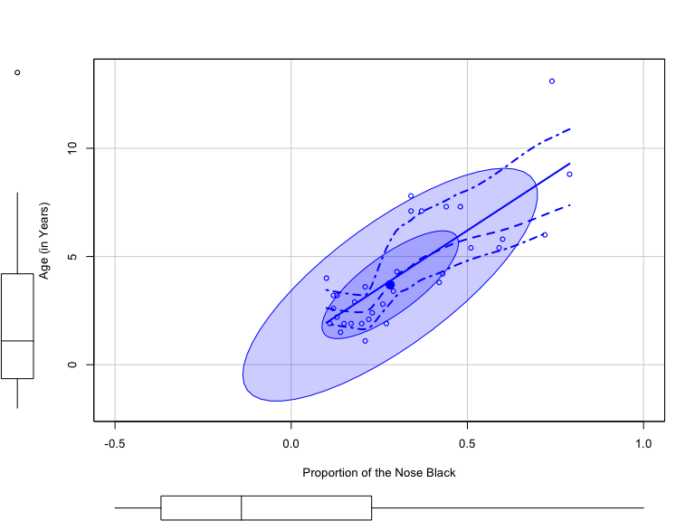

```r
scatterplot(ageInYears ~ proportionBlack, data=lions, ellipse=TRUE, levels=c(0.05, 0.95), reg.line=FALSE, smoother=FALSE, xlab="Proportion of the Nose Black", ylab="Age (in Years)", xlim=c(-0.5, 1), ylim=c(-2, 13.5))
```

Fitting the regression model:

```r
lm.L = lm(ageInYears ~ proportionBlack, data=lions)
summary(lm.L)
```

```
##
## Call:
## lm(formula = ageInYears ~ proportionBlack, data = lions)
##
## Residuals:
##     Min      1Q  Median      3Q     Max
## -2.5449 -1.1117 -0.5285  0.9635  4.3421
##
## Coefficients:
##                 Estimate Std. Error t value Pr(>|t|)
## (Intercept)       0.8790     0.5688   1.545    0.133
## proportionBlack  10.6471     1.5095   7.053 7.68e-08 ***
## ---
## Signif. codes:  0 '***' 0.001 '**' 0.01 '*' 0.05 '.' 0.1 ' ' 1
##
## Residual standard error: 1.669 on 30 degrees of freedom
## Multiple R-squared:  0.6238, Adjusted R-squared:  0.6113
## F-statistic: 49.75 on 1 and 30 DF,  p-value: 7.677e-08
```

Note that the p-value is practically zero so it appears that proportionBlack is related to a lion’s age. How do we interpret this relationship? As follows:

- A unit increase in the proportionBlack leads to an increase of $10.6471$ in the lion’s age. NOTE: The variable is a proportion so a unit increase here would mean going from no black to all black
  - If the proportionBlack $=0.20$ the predicted age is $= 0.8790 + 10.6471(0.20) = 3.00842$
  - If the proportionBlack $=0.21$ the predicted age is $= 0.8790 + 10.6471(0.21) = 3.114891$
  - $3.114891 - 3.00842 = 0.106471$
- The (Intercept) is interpreted as the predicted age _when the proportionBlack $=0$ … which turns out to be 0.8790
- You see the $R^2 = 0.6238$; this is interpreted as the proportion of variance in lions’ ages *explained* by proportionBlack. The closer it is to 1 the more of the variance is being explained. The closer it is to 0 the less the independent variables help us explain the variance in the dependent variable
- You also see the Residual standard error, which tells us how much prediction error, *on average*, we can expect to make if we use this regression model to predict a lion’s age. Obviously the smaller this value the more predictive is the model
- You also see the F-statistic with a p-value. This is a test of the model with no independent variables (NULL) versus the model with $k$ independent variables (FULL) to see if adding the $k$ independent variables explains statistically significantly more variance in the outcome than does the NULL model
  $$F-test = \dfrac{\frac{R^2}{k-1}}{\frac{1 - R^2}{n-k}}$$
- One can compare multiple **nested models** with this $F-test$

## Model-based Predictions

Let us see what the predicted age would be given the proportionBlack in the sample. We’ll generate these predicted ages and then add them to the data-set. We will also do the same for the prediction errors (i.e., $e = y - \hat{y}$)

```r
lions$predicted = predict(lm.L)
lions$errors = residuals(lm.L)
```

Similarly, we can calculate the confidence intervals of the intercept and of the slope $(\hat{b})$

```r
confint(lm.L)
```

```
##                      2.5 %    97.5 %
## (Intercept)     -0.2826733  2.040686
## proportionBlack  7.5643082 13.729931
```

Note the interpretation: We can be about 95% confident that the TRUE slope is anywhere between 7.56 and 13.72. If we wanted the 99% confidence intervals we could do:

```r
confint(lm.L, level=0.99)
```

```
##                      0.5 %    99.5 %
## (Intercept)     -0.6852383  2.443251
## proportionBlack  6.4959997 14.798239
```

## Confidence Intervals and Prediction Intervals

Two sets of intervals can be calculated for the predictions made from the regression model – (1) confidence intervals, and (2) prediction intervals. There is an important difference between these two intervals:

- The confidence interval refers to the **mean predicted value of age** for a given value of proportionBlack
- The prediction interval is calculated for a **single predicted value of age** for a given value of proportionBlack

In generating the confidence interval, since we are trying to make an “average” prediction (mean of $y$) there is less error built into this prediction. Not so for the prediction interval where you want a single $y$ value to be predicted (rather than the mean of $y$) and as such there is more error built into this prediction. Consequently, prediction intervals will be wider than confidence intervals.

Below we generate both sets of intervals and add them to the data-set but we’ll do so with a new data-set we will create with simulated values of proportionBlack.

```r
sim.data = data.frame(proportionBlack = seq(0, 0.94, by=0.03))
predictedCI = predict(lm.L, newdata=sim.data, interval="confidence")
predictedPI = predict(lm.L, newdata=sim.data, interval="predict")
```

Now I’ll add both sets of intervals to the simulated data and predicted age as well.

```r
sim.data = cbind(sim.data, predictedCI, predictedPI[, 2:3])
colnames(sim.data) = c("Simulated.proportionBlack", "Predicted.Age", "LowerCI.Limit", "UpperCI.Limit", "LowerPI.Limit", "UpperPI.Limit")
```

In practice it often helps to show the predicted values of the dependent variable for every value of the independent variable, along with the confidence bands. This is done below:

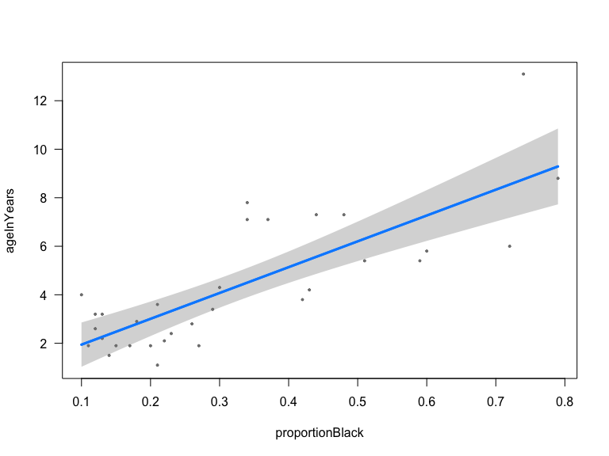

```r
library(visreg)
visreg(lm.L, "proportionBlack")
```

## The NULL Model and the FULL Model

In linear modeling we refer to the NULL model as one that has no independent variables whatsoever. In the case of the lions’ noses data-set this would be a model that has only the intercept. We see the estimates below:

```r
lm.Lnull = lm(ageInYears ~ 1, data=lions)
summary(lm.Lnull)
```

```
##
## Call:
## lm(formula = ageInYears ~ 1, data = lions)
##
## Residuals:
##     Min      1Q  Median      3Q     Max
## -3.2094 -2.1344 -0.8094  1.5406  8.7906
##
## Coefficients:
##             Estimate Std. Error t value Pr(>|t|)
## (Intercept)   4.3094     0.4732   9.108 2.84e-10 ***
## ---
## Signif. codes:  0 '***' 0.001 '**' 0.01 '*' 0.05 '.' 0.1 ' ' 1
##
## Residual standard error: 2.677 on 31 degrees of freedom
```

```r
summary(lions)
```

```
##  proportionBlack    ageInYears       predicted         errors
##  Min.   :0.1000   Min.   : 1.100   Min.   :1.944   Min.   :-2.5449
##  1st Qu.:0.1650   1st Qu.: 2.175   1st Qu.:2.636   1st Qu.:-1.1117
##  Median :0.2650   Median : 3.500   Median :3.700   Median :-0.5285
##  Mean   :0.3222   Mean   : 4.309   Mean   :4.309   Mean   : 0.0000
##  3rd Qu.:0.4325   3rd Qu.: 5.850   3rd Qu.:5.484   3rd Qu.: 0.9635
##  Max.   :0.7900   Max.   :13.100   Max.   :9.290   Max.   : 4.3421
```

The estimated Intercept is 4.3094 … which is basically the mean of ageInYears. Thus, this model is saying if you want to predict a lion’s age with no other information to work with your best bet would be to say it is whatever is the mean value in your sample.

Now the full model, which is basically the one we estimated earlier (*lm.L*)

```r
summary(lm.L)
```

```
##
## Call:
## lm(formula = ageInYears ~ proportionBlack, data = lions)
##
## Residuals:
##     Min      1Q  Median      3Q     Max
## -2.5449 -1.1117 -0.5285  0.9635  4.3421
##
## Coefficients:
##                 Estimate Std. Error t value Pr(>|t|)
## (Intercept)       0.8790     0.5688   1.545    0.133
## proportionBlack  10.6471     1.5095   7.053 7.68e-08 ***
## ---
## Signif. codes:  0 '***' 0.001 '**' 0.01 '*' 0.05 '.' 0.1 ' ' 1
##
## Residual standard error: 1.669 on 30 degrees of freedom
## Multiple R-squared:  0.6238, Adjusted R-squared:  0.6113
## F-statistic: 49.75 on 1 and 30 DF,  p-value: 7.677e-08
```

# Multiple Regression Analysis

Let us take a situation with more than one independent variable. We’ll work with a specific data-set in the **epicalc** package. These data reflect the number of deaths in London from 1st-15th Dec 1952 due to air pollution. Two independent variables are usable – atmospheric smoke (in mg/cu.m), and SO2 (atmospheric sulphur dioxide in parts/million). The dependent variable will be the number of deaths.

```r
library(epicalc)
data(SO2)
```

Let us use only *atmospheric smoke* as an independent variable first.

```r
lm.SO2a = lm(deaths ~ smoke, data=SO2)
summary(lm.SO2a)
```

```
##
## Call:
## lm(formula = deaths ~ smoke, data = SO2)
##
## Residuals:
##     Min      1Q  Median      3Q     Max
## -144.15  -73.33   24.39   54.55  180.39
##
## Coefficients:
##             Estimate Std. Error t value Pr(>|t|)
## (Intercept)   171.82      31.43   5.466 0.000108 ***
## smoke          63.76      15.31   4.164 0.001112 **
## ---
## Signif. codes:  0 '***' 0.001 '**' 0.01 '*' 0.05 '.' 0.1 ' ' 1
##
## Residual standard error: 88.71 on 13 degrees of freedom
## Multiple R-squared:  0.5715, Adjusted R-squared:  0.5386
## F-statistic: 17.34 on 1 and 13 DF,  p-value: 0.001112
```

Now let us add SO2 to the model:

```r
lm.SO2b = lm(deaths ~ smoke + SO2, data=SO2)
summary(lm.SO2b)
```

```
##
## Call:
## lm(formula = deaths ~ smoke + SO2, data = SO2)
##
## Residuals:
##      Min       1Q   Median       3Q      Max
## -100.717  -20.689   -3.298   15.148  114.931
##
## Coefficients:
##             Estimate Std. Error t value Pr(>|t|)
## (Intercept)    89.51      25.08   3.569 0.003858 **
## smoke        -220.32      58.14  -3.789 0.002579 **
## SO2          1051.82     212.60   4.947 0.000338 ***
## ---
## Signif. codes:  0 '***' 0.001 '**' 0.01 '*' 0.05 '.' 0.1 ' ' 1
##
## Residual standard error: 52.96 on 12 degrees of freedom
## Multiple R-squared:  0.859,  Adjusted R-squared:  0.8355
## F-statistic: 36.57 on 2 and 12 DF,  p-value: 7.844e-06
```

We can now test whether lm.SO2b is an improvement over lm.SO2a

```r
anova(lm.SO2b, lm.SO2a)
```

```
## Analysis of Variance Table
##
## Model 1: deaths ~ smoke + SO2
## Model 2: deaths ~ smoke
##   Res.Df    RSS Df Sum of Sq      F    Pr(>F)
## 1     12  33654
## 2     13 102302 -1    -68648 24.478 0.0003378 ***
## ---
## Signif. codes:  0 '***' 0.001 '**' 0.01 '*' 0.05 '.' 0.1 ' ' 1
```

Look at the p-value; it is 0.0003378 and this tells us that adding SO2 improves the model in a statistically significant manner. You can also see this in the increase in the adjusted $R^2$.

You will see the $F-statistic$ reported by R when you run a linear regression model with at least one independent variable. In the lions’ data-set, for example, you had an $F-statistic=49.75$ with a p-value $=7.677e-08$ (see below)

```r
summary(lm.L)
```

```
##
## Call:
## lm(formula = ageInYears ~ proportionBlack, data = lions)
##
## Residuals:
##     Min      1Q  Median      3Q     Max
## -2.5449 -1.1117 -0.5285  0.9635  4.3421
##
## Coefficients:
##                 Estimate Std. Error t value Pr(>|t|)
## (Intercept)       0.8790     0.5688   1.545    0.133
## proportionBlack  10.6471     1.5095   7.053 7.68e-08 ***
## ---
## Signif. codes:  0 '***' 0.001 '**' 0.01 '*' 0.05 '.' 0.1 ' ' 1
##
## Residual standard error: 1.669 on 30 degrees of freedom
## Multiple R-squared:  0.6238, Adjusted R-squared:  0.6113
## F-statistic: 49.75 on 1 and 30 DF,  p-value: 7.677e-08
```

What this was telling us was that adding proportionBlack helped explain more of the variance in lions’ ages.

## Multinomial Categorical Variables

These are categorical variables with more than two values. For example, in some of the ANOVA tests we ran we had three groups. How would we fit and interpret models such as these? Let us see with reference to a specific example – the Zooplankton depredation case. Recall that here we had a three-category treatment indicator: “control”, “low”, and “high. The outcome was *diversity* and we had a blocking indicator as well – the location of each of five sites.

```r
zoop = read.csv(url("http://whitlockschluter.zoology.ubc.ca/wp-content/data/chapter18/chap18e2ZooplanktonDepredation.csv"))
head(zoop); names(zoop); summary(zoop)
```

```
##   treatment diversity block
## 1   control       4.1     1
## 2       low       2.2     1
## 3      high       1.3     1
## 4   control       3.2     2
## 5       low       2.4     2
## 6      high       2.0     2
```

```
## [1] "treatment" "diversity" "block"
```

```
##    treatment   diversity         block
##  control:5   Min.   :1.000   Min.   :1
##  high   :5   1st Qu.:1.400   1st Qu.:2
##  low    :5   Median :2.200   Median :3
##              Mean   :2.133   Mean   :3
##              3rd Qu.:2.550   3rd Qu.:4
##              Max.   :4.100   Max.   :5
```

```r
lm.z = lm(diversity ~ treatment, data=zoop)
summary(lm.z)
```

```
##
## Call:
## lm(formula = diversity ~ treatment, data = zoop)
##
## Residuals:
##    Min     1Q Median     3Q    Max
##  -0.72  -0.44  -0.02   0.31   1.08
##
## Coefficients:
##               Estimate Std. Error t value Pr(>|t|)
## (Intercept)     3.0200     0.2587  11.673 6.57e-08 ***
## treatmenthigh  -1.6400     0.3659  -4.482 0.000749 ***
## treatmentlow   -1.0200     0.3659  -2.788 0.016411 *
## ---
## Signif. codes:  0 '***' 0.001 '**' 0.01 '*' 0.05 '.' 0.1 ' ' 1
##
## Residual standard error: 0.5785 on 12 degrees of freedom
## Multiple R-squared:  0.6307, Adjusted R-squared:  0.5691
## F-statistic: 10.25 on 2 and 12 DF,  p-value: 0.002539
```

Note how the model is estimated:
$$= (Intercept) + b_1(treatment=high) + b_2(treatment=low)$$

- First things first, focus on the missing category (the one not shown in the output) – this is the “control” group.
- Assume you want to predict diversity for the control group. This would mean that treatment=high and treatment = low would be zeroed out.
- This means the (Intercept) now represents the control group and serves as the reference category.
- Predicted diversity for the control group is $=3.02$
- Predicted diversity for the low group is $=3.02 - 1.02 = 2$
- Predicted diversity for the high group is $=3.02 - 1.64 = 1.38$

Note: With a three-category variable, one category is absorbed into the (Intercept) and **dummy variables** are created for the other two categories – $high=1$ if it is the high group and $high=0$ otherwise; $low=1$ if it is the low group and $low=0$ otherwise. With a four-category variable you’ll see three dummy variables being created, and so on. In brief, ONE category will always be absorbed into the (Intercept)

What if we had two categorical variables? Let us see with the lifespans of flies example.

```r
flies = read.csv(url("http://whitlockschluter.zoology.ubc.ca/wp-content/data/chapter18/chap18q07flyLifeSpan.csv"))
head(flies); names(flies); summary(flies)
```

```
##   lifespanDays treatment fertility
## 1            4 high-cost   sterile
## 2            4 high-cost   sterile
## 3            5 high-cost   sterile
## 4           12 high-cost   sterile
## 5           12 high-cost   sterile
## 6           12 high-cost   sterile
```

```
## [1] "lifespanDays" "treatment"    "fertility"
```

```
##   lifespanDays       treatment     fertility
##  Min.   : 2.00   high-cost:420   fertile:420
##  1st Qu.:22.00   low-cost :422   sterile:422
##  Median :27.00
##  Mean   :27.74
##  3rd Qu.:33.00
##  Max.   :56.00
```

Now the model will be estimated as follows:

```r
lm.f = lm(lifespanDays ~ treatment + fertility, data=flies)
summary(lm.f)
```

```
##
## Call:
## lm(formula = lifespanDays ~ treatment + fertility, data = flies)
##
## Residuals:
##      Min       1Q   Median       3Q      Max
## -30.3061  -4.3290   0.8528   4.8528  25.8757
##
## Coefficients:
##                   Estimate Std. Error t value Pr(>|t|)
## (Intercept)        23.1472     0.4926  46.988  < 2e-16 ***
## treatmentlow-cost   6.9771     0.5684  12.276  < 2e-16 ***
## fertilitysterile    2.1819     0.5684   3.839 0.000133 ***
## ---
## Signif. codes:  0 '***' 0.001 '**' 0.01 '*' 0.05 '.' 0.1 ' ' 1
##
## Residual standard error: 8.246 on 839 degrees of freedom
## Multiple R-squared:  0.1649, Adjusted R-squared:  0.1629
## F-statistic: 82.83 on 2 and 839 DF,  p-value: < 2.2e-16
```

Pay attention: The model can be written as
$$= (Intercept) + b_1(low-cost = 1) + b_2(sterile=1)$$

What if it is the high-cost group in the sterile group? Now the model becomes:
$$= (Intercept) + b_2(sterile=1)$$

What if it is the low-cost group in the fertile group? Now the model becomes:
$$= (Intercept) + b_1(low-cost = 1)$$

What if it is the high-cost group in the fertile group? Now the model becomes:
$$= (Intercept)$$

- Predicted life-span for the high-cost fertile group is $23.1472$
- Predicted life-span for the high-cost sterile group is $23.1472 + 2.1819 = 25.3291$
- Predicted life-span for the low-cost fertile group is $23.1472 + 6.9771 = 30.1243$
- Predicted life-span for the low-cost sterile group is $23.1472 + 6.9771 + 2.1819 = 32.3062$

These “effects” of group membership are easy to see with visreg.

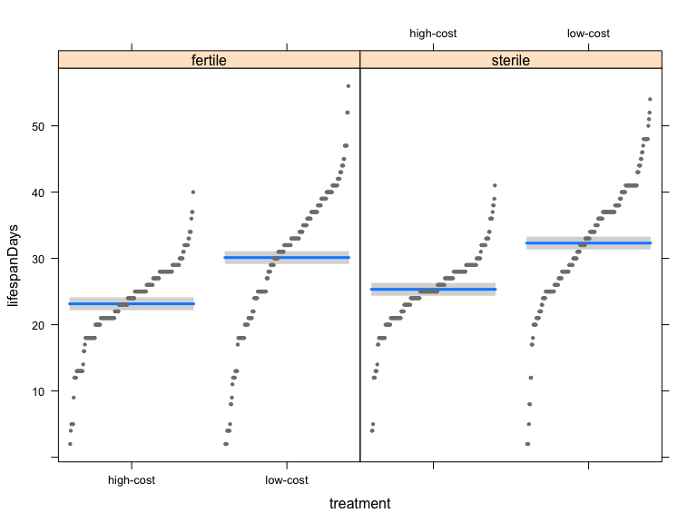

```r
visreg(lm.f, "treatment", by="fertility")
```

## Fitting a Linear Regression Model with Multiple Independent Variables

Few outcomes can be properly describe and modeled by way of a single independent variable. Adding independent variables to the simple model estimated above is very straightforward, just as we extended the One-factor ANOVA to Two-factors. There are some important differences, of course. A key issue is that we now speak of the slopes as **partial slopes** and interpret the effect of each independent variable **holding all else constant**.

Below I demonstrate the process and the interpretation with reference to a particular substantive example.

# Mole Rat Layabouts

Mole rats are the only known mammals with distinct social castes. A single queen and a small number of males are the only reproducing individuals in a colony. Remaining individuals, called workers, gather food, defend the colony, care for the young, and maintain burrows. Recently, it was discovered that there might be two worker castes in the Damaraland mole rat. “Frequent workers” do almost all of the work in the colony, whereas “infrequent workers” do little work except on rare occasions after rains, when they extend the burrow system. To assess the physiological differences between the two types of workers, researchers compared daily energy expenditures of wild mole rats during a dry season. Energy expenditure appeared to vary with body mass in both groups but infrequent workers were heavier than frequent workers. How different is mean daily energy expenditure between the two groups when adjusted for differences in body mass?

```r
rats = read.csv(url("http://whitlockschluter.zoology.ubc.ca/wp-content/data/chapter18/chap18e4MoleRatLayabouts.csv"))
head(rats); names(rats); summary(rats)
```

```
##    caste   lnMass lnEnergy
## 1 worker 3.850148 3.688879
## 2 worker 3.988984 3.688879
## 3 worker 4.110874 3.688879
## 4 worker 4.174387 3.663562
## 5 worker 4.248495 3.871201
## 6 worker 4.262680 3.850148
```

```
## [1] "caste"    "lnMass"   "lnEnergy"
```

```
##     caste        lnMass         lnEnergy
##  lazy  :14   Min.   :3.850   Min.   :3.555
##  worker:21   1st Qu.:4.248   1st Qu.:3.902
##              Median :4.511   Median :4.190
##              Mean   :4.540   Mean   :4.193
##              3rd Qu.:4.844   3rd Qu.:4.489
##              Max.   :5.263   Max.   :5.043
```

We will fit the following model:

$$log(energy) = a + b_1(log(mass)) + b_2(caste) + e$$

```r
lm.r = lm(lnEnergy ~ lnMass + caste, data=rats)
summary(lm.r)
```

```
##
## Call:
## lm(formula = lnEnergy ~ lnMass + caste, data = rats)
##
## Residuals:
##      Min       1Q   Median       3Q      Max
## -0.73388 -0.19371  0.01317  0.17578  0.47673
##
## Coefficients:
##             Estimate Std. Error t value Pr(>|t|)
## (Intercept) -0.09687    0.94230  -0.103   0.9188
## lnMass       0.89282    0.19303   4.625 5.89e-05 ***
## casteworker  0.39334    0.14611   2.692   0.0112 *
## ---
## Signif. codes:  0 '***' 0.001 '**' 0.01 '*' 0.05 '.' 0.1 ' ' 1
##
## Residual standard error: 0.2966 on 32 degrees of freedom
## Multiple R-squared:  0.409,  Adjusted R-squared:  0.3721
## F-statistic: 11.07 on 2 and 32 DF,  p-value: 0.0002213
```

Note a couple of things:

- Both the caste and body mass are significant predictors of energy. Further, energy increases with body mass, and energy is higher *holding body mass constant* for worker rats than it is for lazy rats.
- The adjusted $R^2$ is 0.37, suggesting that some 37% of the variation in energy can be explained by caste and body mass.

Now a more in-depth coverage of the results:

- If we are predicting energy for a worker rat we calculate

$$\hat{lnEnergy} = (Intercept) + b_1(lnMass) + b_2(casteworker)$$

$$= -0.09687 + 0.89282(lnMass) + 0.3934$$

- Set lnMass to some value, say, the mean in the sample $(= 4.540)$ and calculate the predicted lnEnergy

$$= -0.09687 + 0.89282(4.540) + 0.3934 = 4.349933$$

- What if lnMass were the same and we were predicting for a lazy mole rat? Now it would be:

$$\hat{lnEnergy} = (Intercept) + b_1(lnMass)$$

$$= (Intercept) + b_1(lnMass)$$

$$= -0.09687 + 0.89282(4.540) = 3.956533$$

- Note the difference in predicted lnEnergy … $(4.349933 - 3.956533) = 0.3934$ … the value of $\hat{b}_2$

Thus for a categorical variable that only assumes two values (A versus B), the partial slope coefficient estimated for this variable yields a constant difference between category A and B.

With more than one independent variable the **visreg** package really comes in handy to see the predicted values of the outcome.

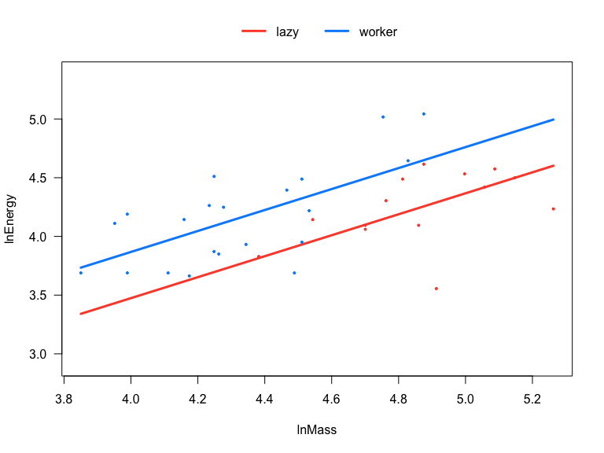

```r
visreg(lm.r, "lnMass", by="caste", overlay=TRUE, band=FALSE)
```

Notice the two sets of parallel lines – one for each caste. The vertical gap between these two lines is the partial slope of caste (0.3934)

If we wanted to use the five-number summary for lnMass and generate predictions for these values we could do the following:

```r
new.data.a = data.frame(lnMass=c(3.850, 4.248, 4.511, 4.844, 5.263 ), caste="worker")
```

We can then use these to generate 5 predicted values of lnEnergy for workers

```r
predicted.lnEnergy.w = predict(lm.r, newdata=new.data.a)
predicted.lnEnergy.w
```

```
##        1        2        3        4        5
## 3.733812 4.089153 4.323963 4.621270 4.995360
```

Likewise, we could generate predictions for caste = “lazy”

```r
new.data.b = data.frame(lnMass=c(3.850, 4.248, 4.511, 4.844, 5.263 ), caste="lazy")
predicted.lnEnergy.l = predict(lm.r, newdata=new.data.b)
predicted.lnEnergy.l
```

```
##        1        2        3        4        5
## 3.340470 3.695810 3.930621 4.227928 4.602018
```

Now let us plot these side-by-side

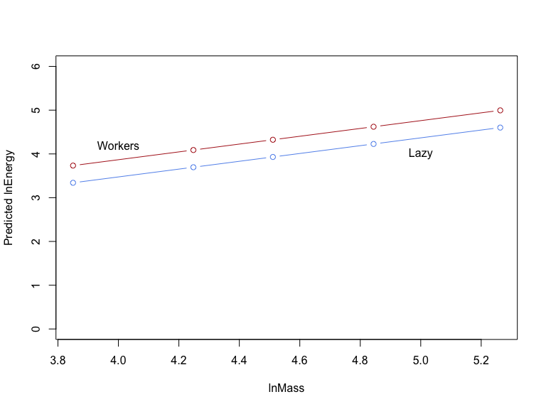

```r
plot(new.data.a$lnMass, predicted.lnEnergy.w, type="b", col="firebrick", ylim=c(0, 6), ylab="Predicted lnEnergy", xlab="lnMass")
par(new=TRUE)
lines(new.data.b$lnMass, predicted.lnEnergy.l, type="b", col="cornflowerblue", ylim=c(0, 6))
text(4, 4.2, "Workers")
text(5, 4, "Lazy")
```

The gap between the two lines is the boost in lnEnergy for workers

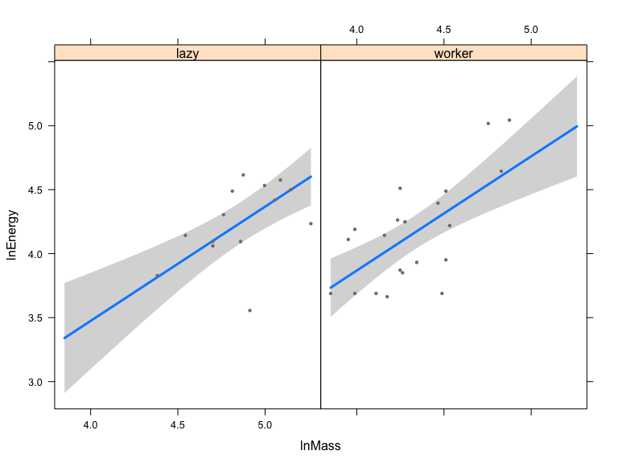

```r
visreg(lm.r, "lnMass", by="caste")
```

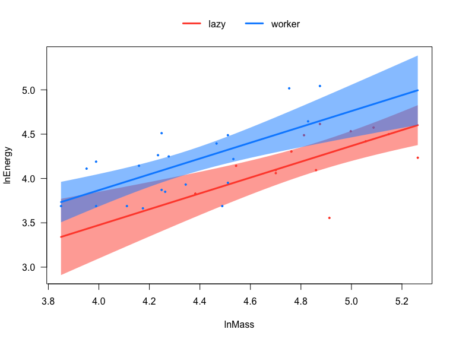

```r
visreg(lm.r, "lnMass", by="caste", overlay=TRUE)
```

## Example of the Population Regression Function

```r
library(HistData)
data(Galton); names(Galton); summary(Galton)
```

```
## [1] "parent" "child"
```

```
##      parent          child
##  Min.   :64.00   Min.   :61.70
##  1st Qu.:67.50   1st Qu.:66.20
##  Median :68.50   Median :68.20
##  Mean   :68.31   Mean   :68.09
##  3rd Qu.:69.50   3rd Qu.:70.20
##  Max.   :73.00   Max.   :73.70
```

Galton (1886) presented these data in a table, showing a cross-tabulation of 928 adult children born to 205 fathers and mothers, by their height and their mid-parent’s height. He visually smoothed the bivariate frequency distribution and showed that the contours formed concentric and similar ellipses, thus setting the stage for correlation, regression and the bivariate normal distribution.

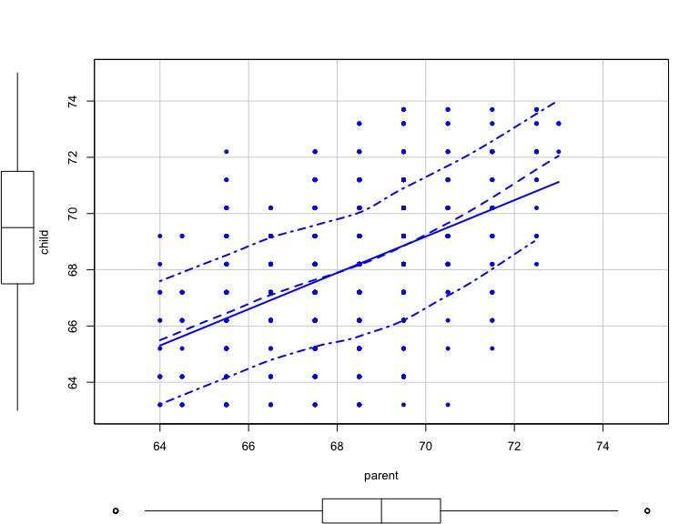

```r
scatterplot(child ~ parent, data=Galton, pch=16,  ellipse=FALSE, levels=c(0.5, 0.95), reg.line=lm, smoother=FALSE, xlim=c(63,75), ylim=c(63,75))
```

Draw four random samples of parents’ height for each value of child’s height. The sample size is set to 40 so you can tweak that number in the command below to get larger or smaller samples.

```r
randomSample = function(df,n) {     return (df[sample(nrow(df), n),]) }
sample1 <- randomSample(Galton, 40)
sample2 <- randomSample(Galton, 40)
sample3 <- randomSample(Galton, 40)
sample4 <- randomSample(Galton, 40)
```

Graphing the 4 scatterplots to see how they look:

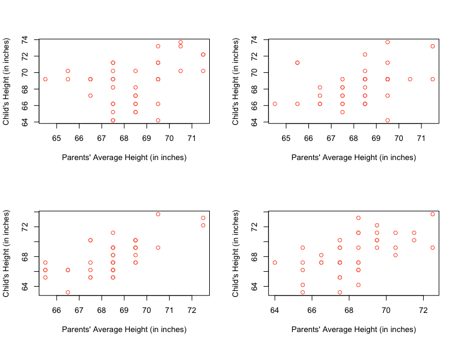

```r
par(mfrow=c(2,2))
plot(sample1$parent, sample1$child, col="tomato1",
     xlab="Parents' Average Height (in inches)",
     ylab = "Child's Height (in inches)")
plot(sample2$parent, sample2$child, col="tomato1",
     xlab="Parents' Average Height (in inches)",
     ylab = "Child's Height (in inches)")
plot(sample3$parent, sample3$child, col="tomato1",
     xlab="Parents' Average Height (in inches)",
     ylab = "Child's Height (in inches)")
plot(sample4$parent, sample4$child, col="tomato1",
     xlab="Parents' Average Height (in inches)",
     ylab = "Child's Height (in inches)")
```

```r
par(mfrow=c(1,1))
```

Now adding the regression line estimated in each sample to the scatterplot for each of the preceding scatterplots:

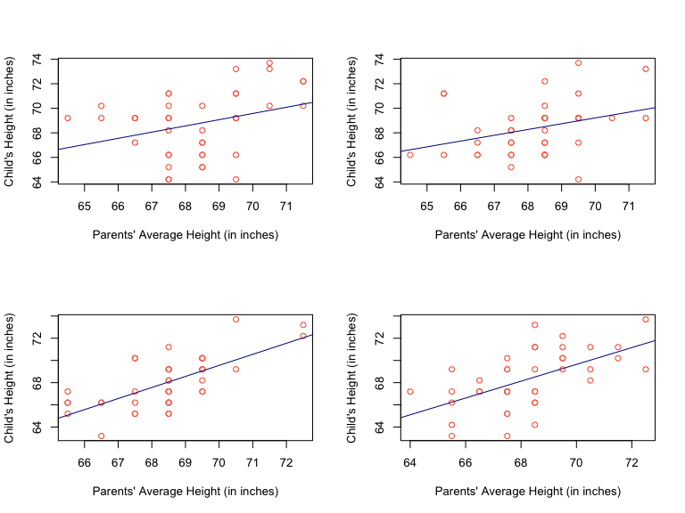

```r
par(mfrow=c(2,2))
plot(sample1$parent, sample1$child, col="tomato1",
     xlab="Parents' Average Height (in inches)",
     ylab = "Child's Height (in inches)")
abline(lm(sample1$child ~ sample1$parent), col="darkblue")
plot(sample2$parent, sample2$child, col="tomato1",
     xlab="Parents' Average Height (in inches)",
     ylab = "Child's Height (in inches)")
abline(lm(sample2$child ~ sample2$parent), col="darkblue")
plot(sample3$parent, sample3$child, col="tomato1",
     xlab="Parents' Average Height (in inches)",
     ylab = "Child's Height (in inches)")
abline(lm(sample3$child ~ sample3$parent), col="darkblue")
plot(sample4$parent, sample4$child, col="tomato1",
     xlab="Parents' Average Height (in inches)",
     ylab = "Child's Height (in inches)")
abline(lm(sample4$child ~ sample4$parent), col="darkblue")
```

```r
par(mfrow=c(1,1))
```

Estimating and seeing the results of the Population Regression Function for Galton’s data:

```r
model4 <- lm(Galton$child ~ Galton$parent)
summary(model4)
```

```
##
## Call:
## lm(formula = Galton$child ~ Galton$parent)
##
## Residuals:
##     Min      1Q  Median      3Q     Max
## -7.8050 -1.3661  0.0487  1.6339  5.9264
##
## Coefficients:
##               Estimate Std. Error t value Pr(>|t|)
## (Intercept)   23.94153    2.81088   8.517   <2e-16 ***
## Galton$parent  0.64629    0.04114  15.711   <2e-16 ***
## ---
## Signif. codes:  0 '***' 0.001 '**' 0.01 '*' 0.05 '.' 0.1 ' ' 1
##
## Residual standard error: 2.239 on 926 degrees of freedom
## Multiple R-squared:  0.2105, Adjusted R-squared:  0.2096
## F-statistic: 246.8 on 1 and 926 DF,  p-value: < 2.2e-16
```

Estimating and seeing the results of the Sample Regression Function:

```r
model4.1 <- lm(sample1$child ~ sample1$parent)
summary(model4.1)
```

```
##
## Call:
## lm(formula = sample1$child ~ sample1$parent)
##
## Residuals:
##     Min      1Q  Median      3Q     Max
## -5.1197 -2.1071  0.1334  1.8803  3.8803
##
## Coefficients:
##                Estimate Std. Error t value Pr(>|t|)
## (Intercept)     34.1317    16.5071   2.068   0.0455 *
## sample1$parent   0.5063     0.2414   2.097   0.0427 *
## ---
## Signif. codes:  0 '***' 0.001 '**' 0.01 '*' 0.05 '.' 0.1 ' ' 1
##
## Residual standard error: 2.499 on 38 degrees of freedom
## Multiple R-squared:  0.1037, Adjusted R-squared:  0.08013
## F-statistic: 4.398 on 1 and 38 DF,  p-value: 0.0427
```

```r
model4.2 <- lm(sample2$child ~ sample2$parent)
summary(model4.2)
```

```
##
## Call:
## lm(formula = sample2$child ~ sample2$parent)
##
## Residuals:
##     Min      1Q  Median      3Q     Max
## -4.7746 -1.3183 -0.0392  0.6962  4.7254
##
## Coefficients:
##                Estimate Std. Error t value Pr(>|t|)
## (Intercept)     36.2493    14.3739   2.522   0.0160 *
## sample2$parent   0.4709     0.2107   2.235   0.0314 *
## ---
## Signif. codes:  0 '***' 0.001 '**' 0.01 '*' 0.05 '.' 0.1 ' ' 1
##
## Residual standard error: 2.047 on 38 degrees of freedom
## Multiple R-squared:  0.1162, Adjusted R-squared:  0.09289
## F-statistic: 4.994 on 1 and 38 DF,  p-value: 0.03139
```

```r
model4.3 <- lm(sample3$child ~ sample3$parent)
summary(model4.3)
```

```
##
## Call:
## lm(formula = sample3$child ~ sample3$parent)
##
## Residuals:
##     Min      1Q  Median      3Q     Max
## -2.8702 -1.1142  0.1358  1.1378  3.6458
##
## Coefficients:
##                Estimate Std. Error t value Pr(>|t|)
## (Intercept)     -0.1629    11.6161  -0.014    0.989
## sample3$parent   0.9960     0.1697   5.869 8.62e-07 ***
## ---
## Signif. codes:  0 '***' 0.001 '**' 0.01 '*' 0.05 '.' 0.1 ' ' 1
##
## Residual standard error: 1.721 on 38 degrees of freedom
## Multiple R-squared:  0.4754, Adjusted R-squared:  0.4616
## F-statistic: 34.44 on 1 and 38 DF,  p-value: 8.624e-07
```

```r
model4.4 <- lm(sample4$child ~ sample4$parent)
summary(model4.4)
```

```
##
## Call:
## lm(formula = sample4$child ~ sample4$parent)
##
## Residuals:
##     Min      1Q  Median      3Q     Max
## -4.5542 -1.4397  0.0813  1.4458  4.6888
##
## Coefficients:
##                Estimate Std. Error t value Pr(>|t|)
## (Intercept)     16.6565    11.8658   1.404    0.169
## sample4$parent   0.7570     0.1738   4.355 9.71e-05 ***
## ---
## Signif. codes:  0 '***' 0.001 '**' 0.01 '*' 0.05 '.' 0.1 ' ' 1
##
## Residual standard error: 2.139 on 38 degrees of freedom
## Multiple R-squared:  0.3329, Adjusted R-squared:  0.3154
## F-statistic: 18.97 on 1 and 38 DF,  p-value: 9.714e-05
```

```r
library(stargazer)
stargazer(model4, model4.1, model4.2, model4.3, model4.4, type="html", column.labels = c("Population", "Sample 1", "Sample 2", "Sample 3", "Sample 4"), column.separate = c(1, 1, 1, 1, 1), digits=2)
```

|  | *Dependent variable:* |  |  |  |  |
| --- | --- | --- | --- | --- | --- |
|  | child | child | child | child | child |
|  | Population | Sample 1 | Sample 2 | Sample 3 | Sample 4 |
|  | (1) | (2) | (3) | (4) | (5) |
| parent | 0.65*** |  |  |  |  |
|  | (0.04) |  |  |  |  |
| parent |  | 0.51** |  |  |  |
|  |  | (0.24) |  |  |  |
| parent |  |  | 0.47** |  |  |
|  |  |  | (0.21) |  |  |
| parent |  |  |  | 1.00*** |  |
|  |  |  |  | (0.17) |  |
| parent |  |  |  |  | 0.76*** |
|  |  |  |  |  | (0.17) |
| Constant | 23.94*** | 34.13** | 36.25** | -0.16 | 16.66 |
|  | (2.81) | (16.51) | (14.37) | (11.62) | (11.87) |
| Observations | 928 | 40 | 40 | 40 | 40 |
| R<sup>2</sup> | 0.21 | 0.10 | 0.12 | 0.48 | 0.33 |
| Adjusted R<sup>2</sup> | 0.21 | 0.08 | 0.09 | 0.46 | 0.32 |
| Residual Std. Error | 2.24 (df = 926) | 2.50 (df = 38) | 2.05 (df = 38) | 1.72 (df = 38) | 2.14 (df = 38) |
| F Statistic | 246.84*** (df = 1; 926) | 4.40** (df = 1; 38) | 4.99** (df = 1; 38) | 34.44*** (df = 1; 38) | 18.97*** (df = 1; 38) |
| *Note:* | p<0.1; p<0.05; p<0.01 |  |  |  |  |

Note how the samples vary in terms of the estimates that result. In essence, you could end up with any one of these random samples and be some ways off from the TRUE population parameters.